# Air Quality :VAR MODEL

## Members

- ANDREW KARANJA
- SUHAYMA ALI HARITH
- JULIET WANJIRU
- HAPPY KULOLA
- ALEX WAWERU

# Importing Data

## Region 1

```r
Region_1=read.csv("Region A.csv")
head(Region_1,4)
```

|  | Date | Temp | Humid | p1 | p2 |
| --- | --- | --- | --- | --- | --- |
| 1 | 2018-01-01 | NA | NA | NA | NA |
| 2 | 2018-01-02 | NA | NA | NA | NA |
| 3 | 2018-01-03 | NA | NA | NA | NA |
| 4 | 2018-01-04 | NA | NA | NA | NA |

```r
#Selecting the data from the first day we had an active reading in region 1
Region_1=Region_1[281:length(Region_1$Date),]
```

## Region 2

```r
Region_2=read.csv("Region B.csv")
head(Region_2,4)
```

|  | Date | Temp | Humid | p1 | p2 |
| --- | --- | --- | --- | --- | --- |
| 1 | 2018-01-01 | NA | NA | NA | NA |
| 2 | 2018-01-02 | NA | NA | NA | NA |
| 3 | 2018-01-03 | NA | NA | NA | NA |
| 4 | 2018-01-04 | NA | NA | NA | NA |

```r
#Selecting the data from the first day we had an active reading in region 2
Region_2=Region_2[66:length(Region_2$Date),]
```

> The days containing missing values indicate that that particlular day no data was collected in that region

# EDA

## Region 1

```r
summarytools::view(dfSummary(Region_1,graph.col = F))
```

## Region 2

```r
summarytools::view(dfSummary(Region_2,graph.col = F))
```

# Data Manipulation

Creating new variables extracted from date and reshaping the data

```r
#Creating a data frame
Data=rbind(data.frame(Region_1,Region=rep("A",length(Region_1$Date))),
           data.frame(Region_2,Region=rep("B",length(Region_2$Date))))

#Creating a variable day
Data$Day=lubridate::wday(Data$Date,label = T)

#Creating a variable month
Data$Month=lubridate::month(Data$Date,label = T)

#Creating a variable year
Data$Year=factor(lubridate::year(Data$Date))

#Reshaping the data
Data=Data %>% gather('Value_Type','Value',
                             -c('Date','Day','Month','Year','Region'))
```

## Removing Outliers

```r
R=unique(Data$Region)
Vt=unique(Data$Value_Type)

for(i in R){
  for (j in Vt) {
   Outlier=boxplot.stats(Data$Value[which(Data$Region==paste(i) &
                                 Data$Value_Type==paste(j))])$out
   Data = Data %>% filter(!(Value %in% Outlier))
  }
}
```

# Distribution

## Temperature

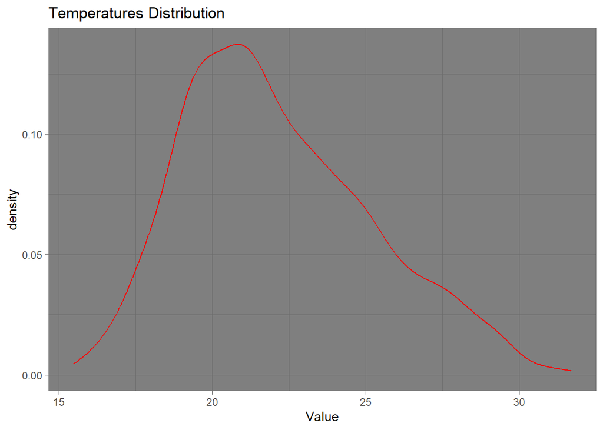

```r
Data %>% filter(Value_Type=="Temp") %>%
  ggplot(aes(Value)) +
  geom_density(col="red") +
  theme_dark() +
  ggtitle("Temperatures Distribution")
```

## Humidity

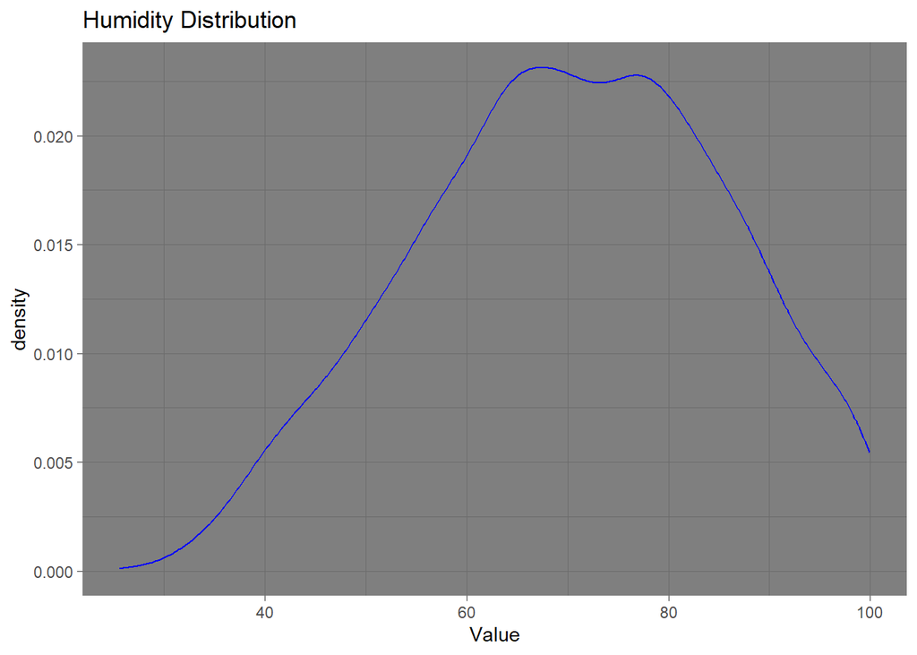

```r
Data %>% filter(Value_Type=="Humid") %>%
  ggplot(aes(Value)) +
  geom_density(col="blue") +
  theme_dark()+
  ggtitle("Humidity Distribution")
```

## Particulate matter 1

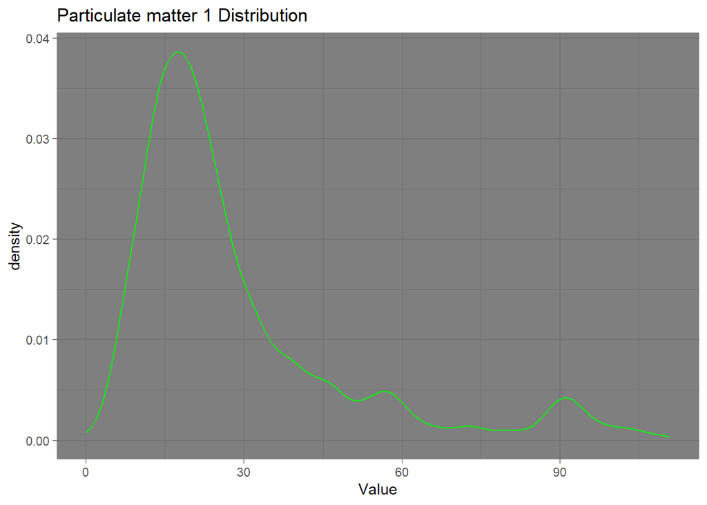

```r
Data %>% filter(Value_Type=="p1") %>%
  ggplot(aes(Value)) +
  geom_density(col="green") +
  theme_dark()+
  ggtitle("Particulate matter 1 Distribution")
```

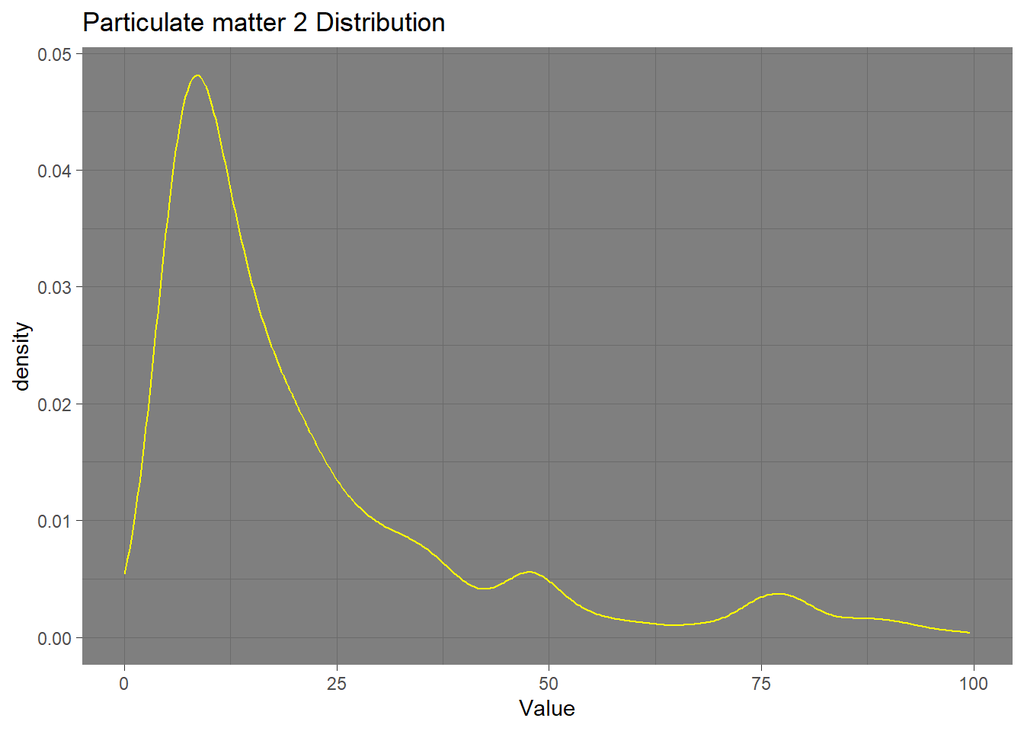

```r
Data %>% filter(Value_Type=="p2") %>%
  ggplot(aes(Value)) +
  geom_density(col="yellow") +
  theme_dark()+
  ggtitle("Particulate matter 2 Distribution")
```

# Visualization

## Yearly Analysis

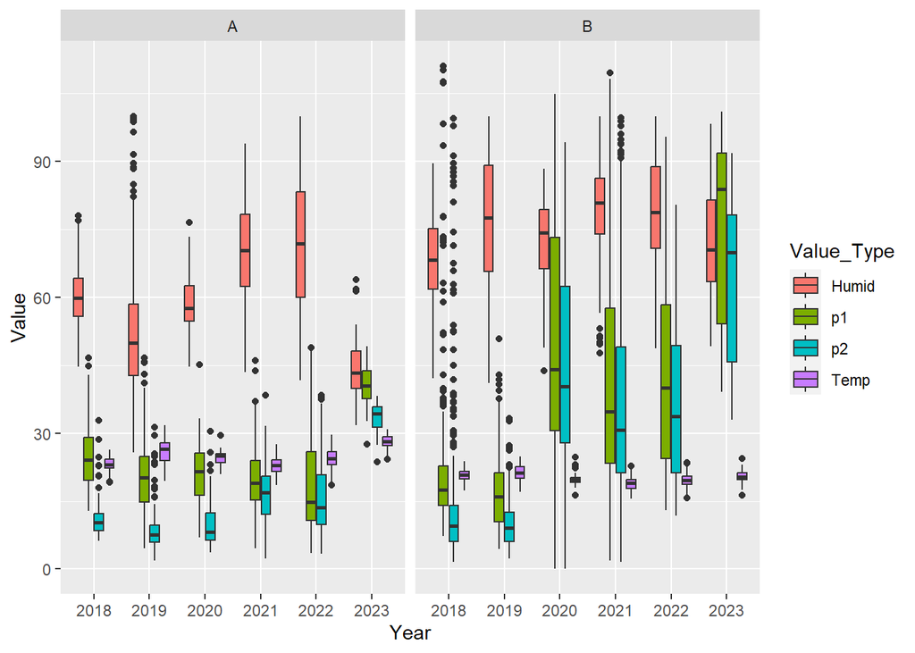

```r
Data %>% #filter(Value_Type=="Temp") %>%
  ggplot(aes(x=Year,y=Value,fill=Value_Type)) +
  geom_boxplot() +
  facet_wrap(~Region)
```

## Monthly Analysis

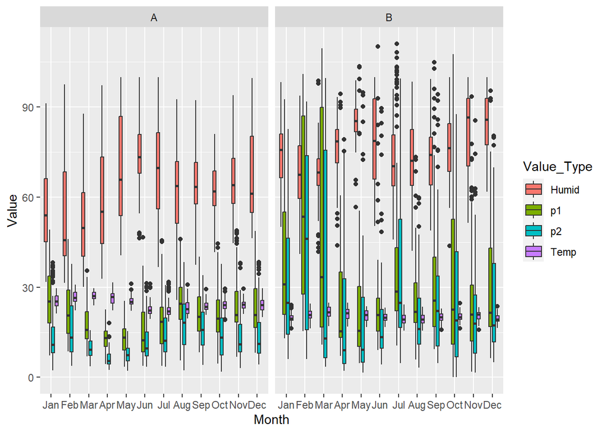

```r
Data %>% #filter(Value_Type=="Temp") %>%
  ggplot(aes(x=Month,y=Value,fill=Value_Type)) +
  geom_boxplot() +
  facet_wrap(~Region)
```

## Daily Analysis

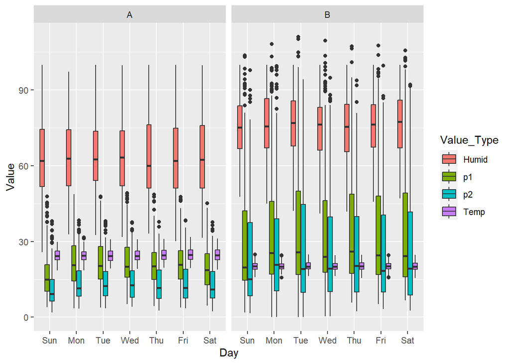

```r
Data %>% ggplot(aes(x=Day,y=Value,fill=Value_Type)) +
  geom_boxplot() +
  facet_wrap(~Region)
```

## Table

```r
Data %>% group_by(Value_Type,Region,Year,Month) %>%
         summarise(Value=mean(Value,na.rm=T),.groups = "keep") %>%
  spread(Value_Type,Value)
```

| Region | Year | Month | Humid | p1 | p2 | Temp |
| --- | --- | --- | --- | --- | --- | --- |
| A | 2018 | Oct | 64.68900 | 24.115440 | 10.125653 | 21.70136 |
| A | 2018 | Nov | 60.57501 | 25.166112 | 11.364486 | 23.11878 |
| A | 2018 | Dec | 56.79008 | 24.996133 | 12.879215 | 24.56441 |
| A | 2019 | Jan | 46.91707 | 27.257026 | 9.322977 | 26.04584 |
| A | 2019 | Feb | 42.90991 | 21.373635 | 7.514383 | 27.06456 |
| A | 2019 | Mar | 40.27094 | 22.910976 | 7.771559 | 28.11931 |
| A | 2019 | Apr | 47.83444 | 14.517434 | 5.541750 | 27.54354 |
| A | 2019 | May | 53.24091 | 16.319590 | 6.490632 | 26.10664 |
| A | 2019 | Jun | 66.08716 | 21.666000 | 11.172252 | 23.71116 |
| A | 2019 | Jul | 49.55647 | 23.968924 | 11.385492 | 25.90732 |

[output cut: 103 more lines]

# Vector Auto-Regression (VAR)

## Converting data to a time series

```r
Region_1ts=ts(Region_1[-1],frequency = 365,
              start = c(2018,282))

Region_2ts=ts(Region_2[-1],frequency = 365,
              start = c(2018,67))
```

## Replacing outliers present in the two regions time series data

```r
#Detecting outliers and replacing them
for(i in 1:4){
  uni=Region_1ts[,i]
  for(j in 1:length(tsoutliers(uni)$index)){
    Region_1ts[tsoutliers(uni)$index[j],i]=tsoutliers(uni)$replacements[j]
  }
}

for(i in 1:4){
  uni=Region_2ts[,i]
  for(j in 1:length(tsoutliers(uni)$index)){
    Region_2ts[tsoutliers(uni)$index[j],i]=tsoutliers(uni)$replacements[j]
  }
}
```

## Handling missing values

### Region 1

```r
# Visualization
any(is.na(Region_1))
```

```
## [1] TRUE
```

```r
colSums(is.na(Region_1))
```

```
##  Date  Temp Humid    p1    p2
##     0   569   569   531   531
```

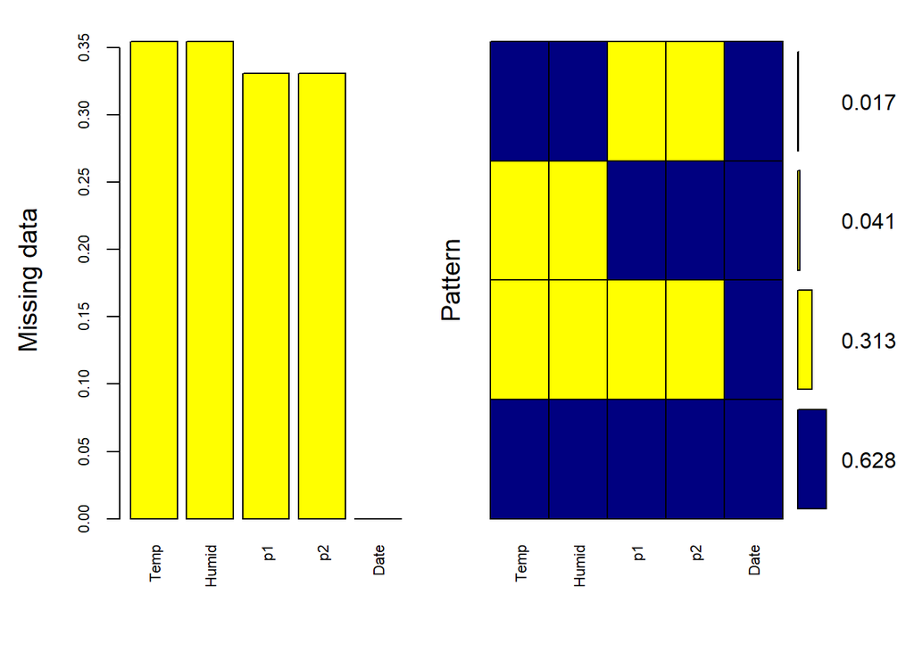

```
##
##  Variables sorted by number of missings:
##  Variable     Count
##      Temp 0.3545171
##     Humid 0.3545171
##        p1 0.3308411
##        p2 0.3308411
##      Date 0.0000000
```

```r
aggr(Region_1, col=c('navyblue','yellow'),
                    numbers=TRUE, sortVars=TRUE,
                    labels=names("Region 1"), cex.axis=.7,
                    gap=3, ylab=c("Missing data","Pattern"))
```

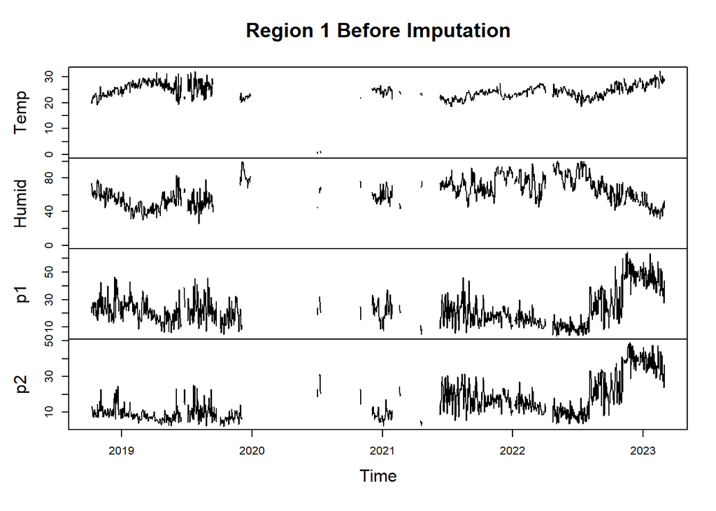

```r
plot(Region_1ts, main="Region 1 Before Imputation")
```

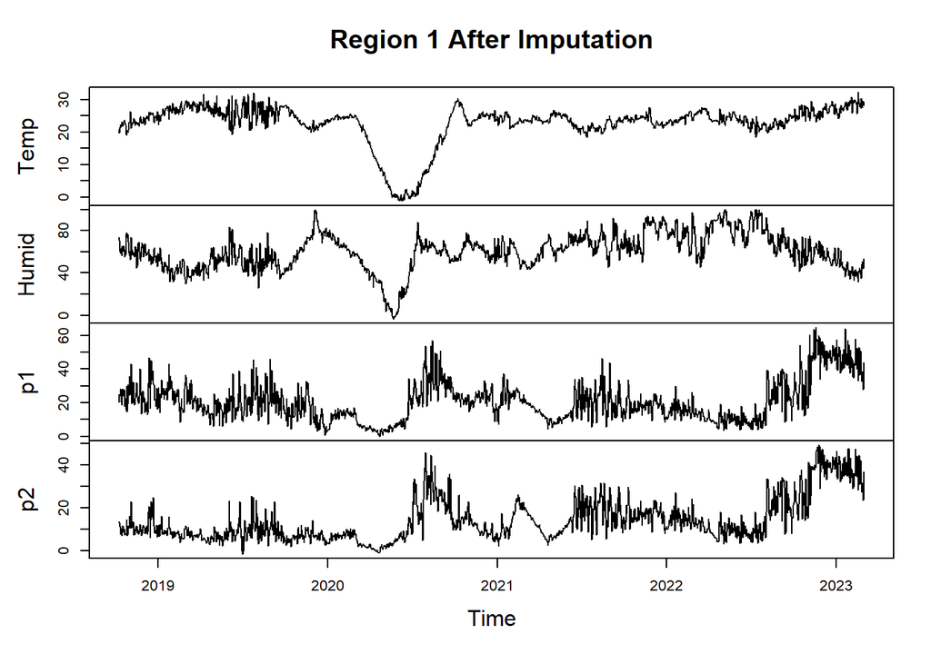

```r
# Missing values imputation
Region_1imputed=na_seadec(Region_1ts)

#After Imputation
plot(Region_1imputed, main="Region 1 After Imputation")
```

### Region 2

```r
# Visualization
any(is.na(Region_2))
```

```
## [1] TRUE
```

```r
colSums(is.na(Region_2))
```

```
##  Date  Temp Humid    p1    p2
##     0   529   529   502   502
```

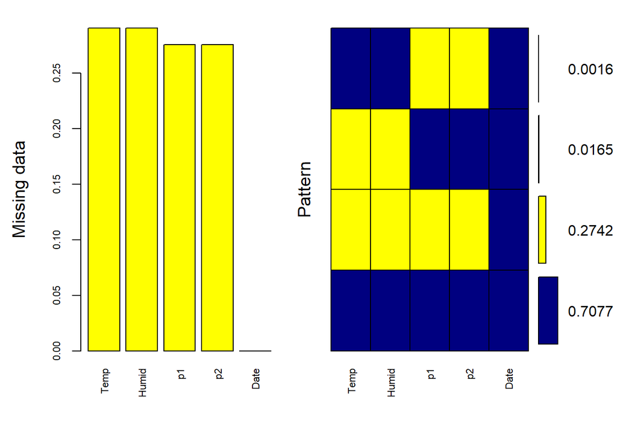

```
##
##  Variables sorted by number of missings:
##  Variable     Count
##      Temp 0.2906593
##     Humid 0.2906593
##        p1 0.2758242
##        p2 0.2758242
##      Date 0.0000000
```

```r
aggr(Region_2, col=c('navyblue','yellow'),
                    numbers=TRUE, sortVars=TRUE,
                    labels=names("Region 2"), cex.axis=.7,
                    gap=3, ylab=c("Missing data","Pattern"))
```

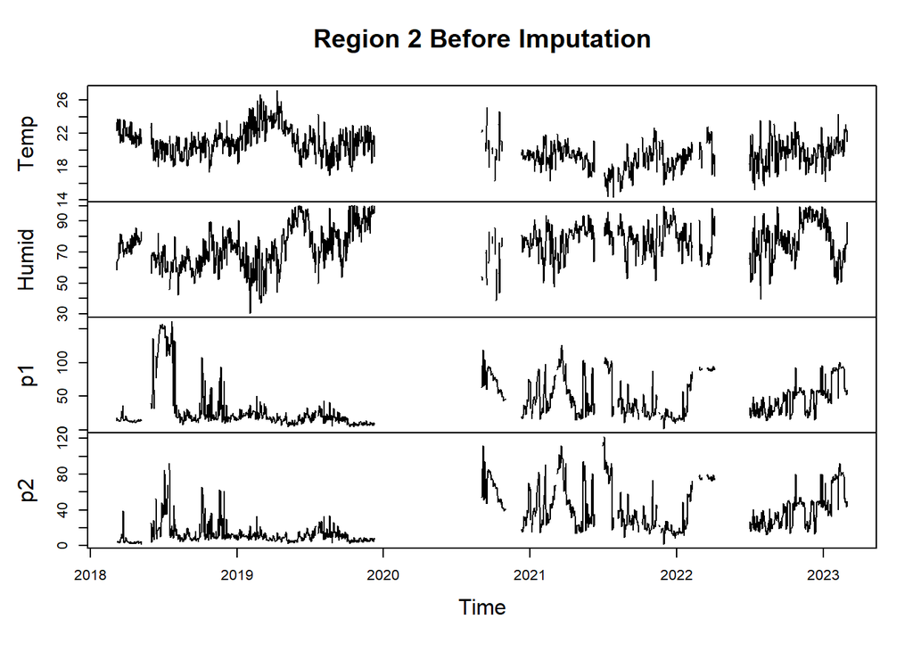

```r
# Before imputation
plot(Region_2ts, main="Region 2 Before Imputation")
```

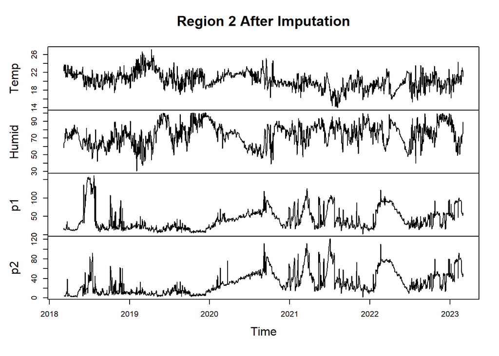

```r
# Missing values imputation
Region_2imputed=na_seadec(Region_2ts)

#After Imputation
plot(Region_2imputed, main="Region 2 After Imputation")
```

## Granger’s Causality Test

```r
#Test of causality between Temp and humidity
grangertest(Region_1imputed[,1],Region_1imputed[,2],order = 2)$`Pr(>F)`
```

```
## [1]          NA 0.002498177
```

```r
grangertest(Region_2imputed[,1],Region_2imputed[,2],order = 2)$`Pr(>F)`
```

```
## [1]           NA 9.649402e-14
```

```r
#Test of causality between P1 and P2
grangertest(Region_1imputed[,4],Region_1imputed[,3],order = 2)$`Pr(>F)`
```

```
## [1]          NA 0.001140163
```

```r
grangertest(Region_2imputed[,4],Region_2imputed[,3],order = 2)$`Pr(>F)`
```

```
## [1]           NA 5.978578e-05
```

```r
#Test of causality between humid and P1
grangertest(Region_1imputed[,2],Region_1imputed[,3],order = 2)$`Pr(>F)`
```

```
## [1]        NA 0.5588874
```

```r
grangertest(Region_2imputed[,2],Region_2imputed[,3],order = 2)$`Pr(>F)`
```

```
## [1]          NA 0.008883094
```

## Test Stationarity

### Region 1

Augmented Dickey-Fuller test for the null hypothesis that x is non-stationary.

```r
lapply(Region_1imputed,adfTest,lags=1,type="nc")
```

```
## $Temp
##
## Title:
##  Augmented Dickey-Fuller Test
##
## Test Results:
##   PARAMETER:
##     Lag Order: 1
##   STATISTIC:
##     Dickey-Fuller: -0.6165
##   P VALUE:
##     0.4199
##
## Description:
##  Wed Apr 26 12:39:34 2023 by user: wawer
##
## $Humid
##
## Title:
##  Augmented Dickey-Fuller Test
##
## Test Results:
##   PARAMETER:
##     Lag Order: 1
##   STATISTIC:
##     Dickey-Fuller: -1.6101
##   P VALUE:
##     0.1031
##
## Description:
##  Wed Apr 26 12:39:34 2023 by user: wawer
##
## $p1
##
## Title:
##  Augmented Dickey-Fuller Test
##
## Test Results:
##   PARAMETER:
##     Lag Order: 1
```

[output cut: 8 more lines]

```
## $p2
##
## Title:
##  Augmented Dickey-Fuller Test
##
## Test Results:
##   PARAMETER:
##     Lag Order: 1
##   STATISTIC:
##     Dickey-Fuller: -3.3315
##   P VALUE:
##     0.01
##
## Description:
##  Wed Apr 26 12:39:34 2023 by user: wawer
```

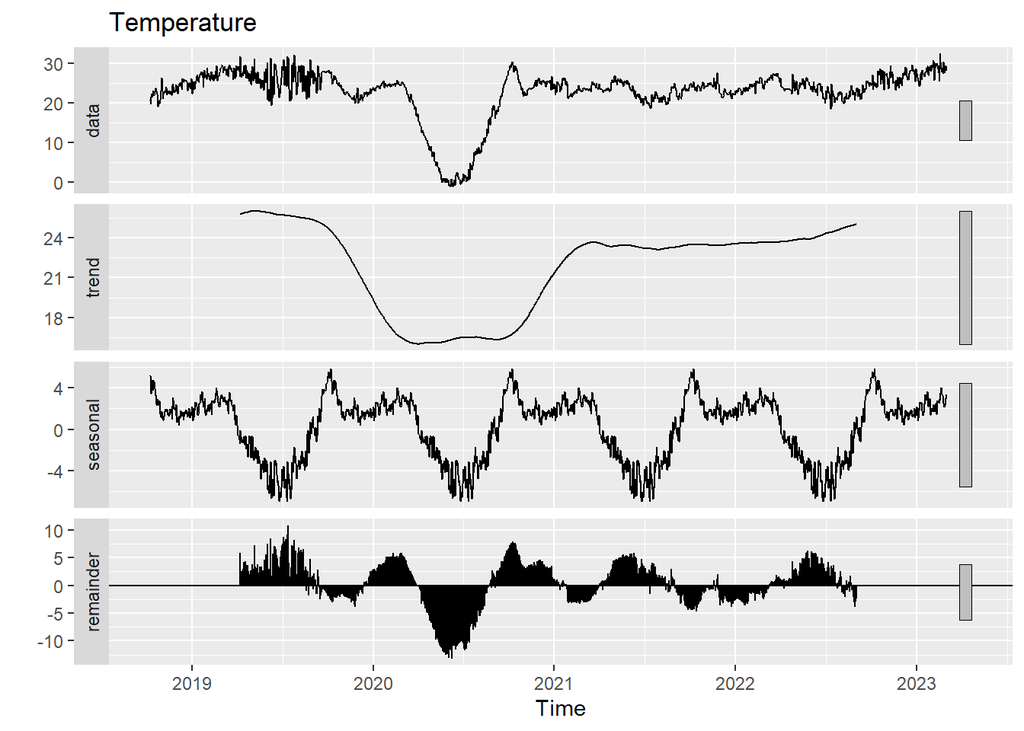

```r
## Decomposition
autoplot(decompose(Region_1imputed[,1]),main="Temperature")
```

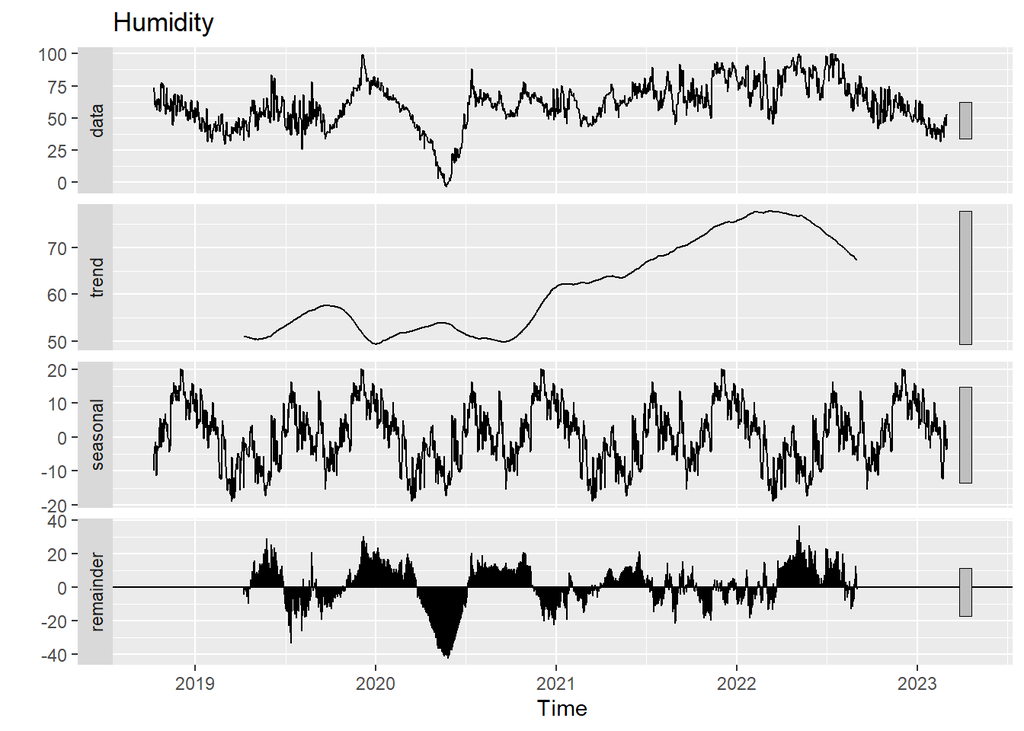

```r
autoplot(decompose(Region_1imputed[,2]),main="Humidity")
```

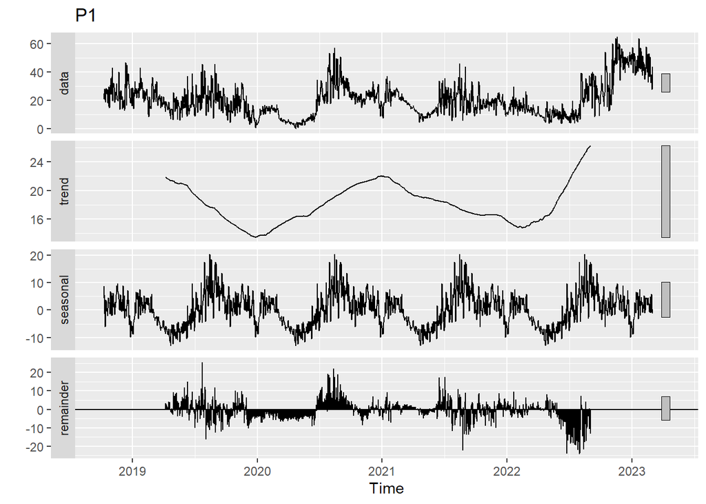

```r
autoplot(decompose(Region_1imputed[,3]),main="P1")
```

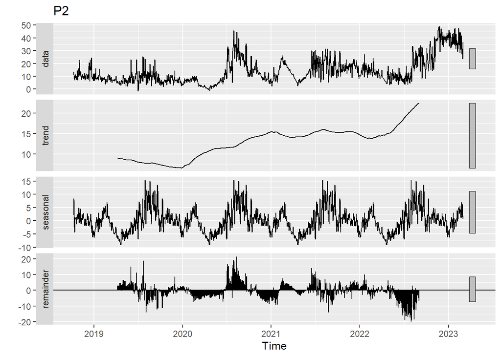

```r
autoplot(decompose(Region_1imputed[,4]),main="P2")
```

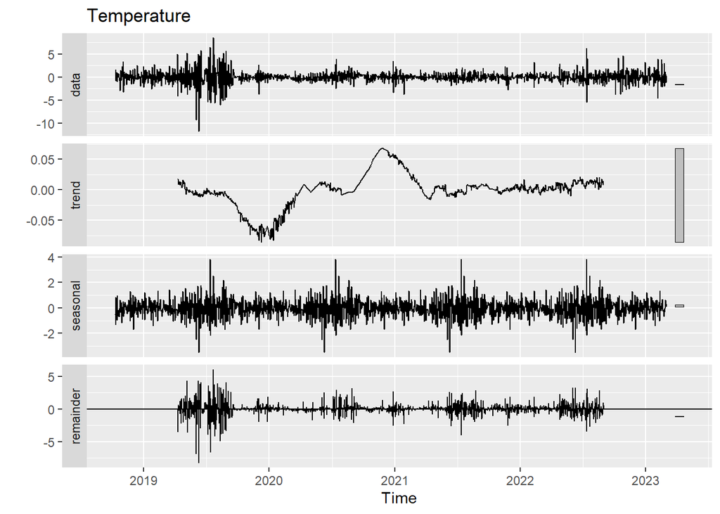

```r
## Differencing
Region1_diff=diff(Region_1imputed,lag = 1)

autoplot(decompose(Region1_diff[,1]),main="Temperature")
```

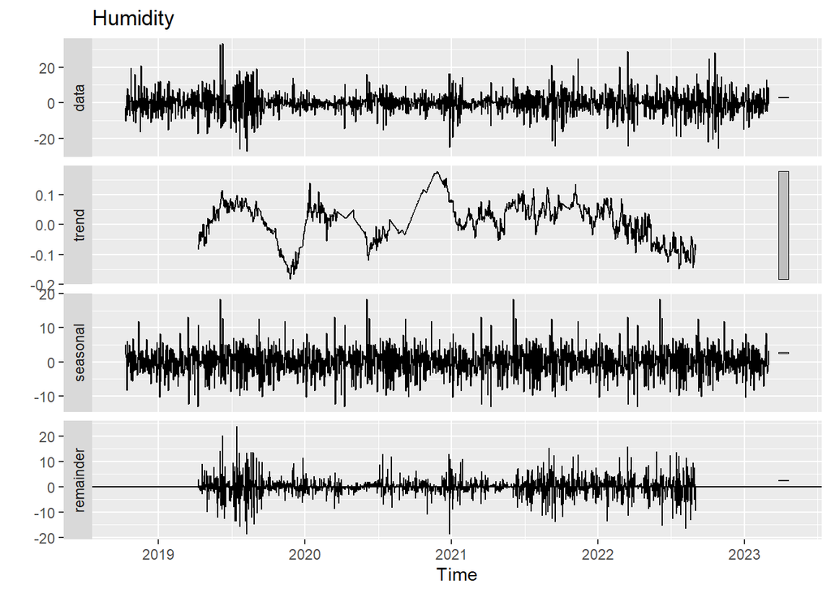

```r
autoplot(decompose(Region1_diff[,2]),main="Humidity")
```

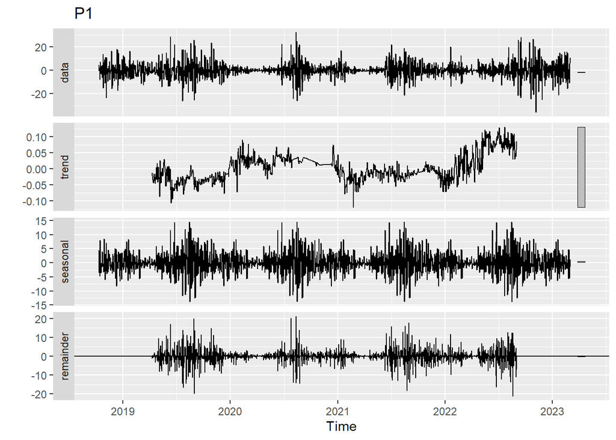

```r
autoplot(decompose(Region1_diff[,3]),main="P1")
```

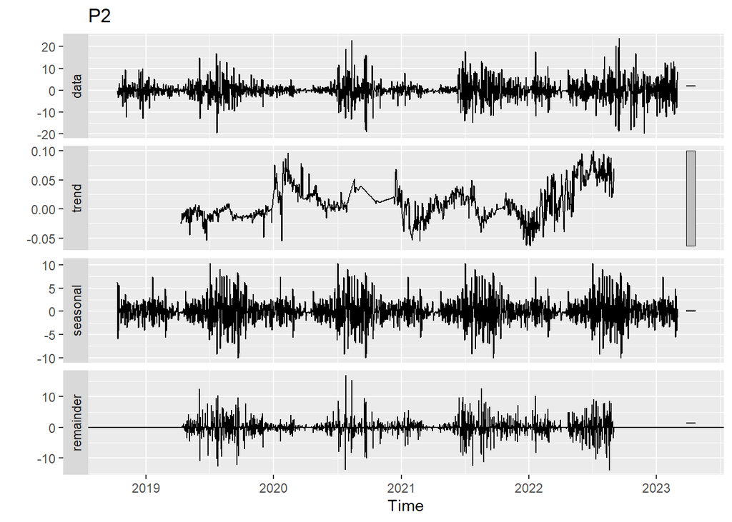

```r
autoplot(decompose(Region1_diff[,4]),main="P2")
```

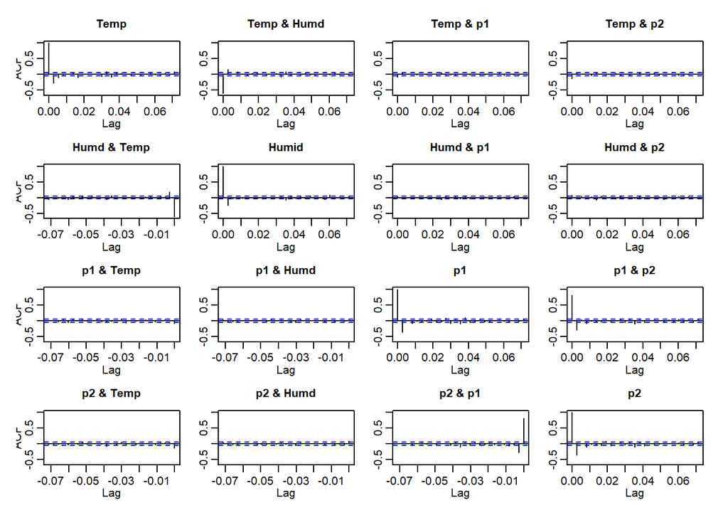

```r
acf(Region1_diff)
```

### Region 2

```r
lapply(Region_2imputed,adfTest,lags=1, type="nc")
```

```
## $Temp
##
## Title:
##  Augmented Dickey-Fuller Test
##
## Test Results:
##   PARAMETER:
##     Lag Order: 1
##   STATISTIC:
##     Dickey-Fuller: -0.9324
##   P VALUE:
##     0.3191
##
## Description:
##  Wed Apr 26 12:39:46 2023 by user: wawer
##
## $Humid
##
## Title:
##  Augmented Dickey-Fuller Test
##
## Test Results:
##   PARAMETER:
##     Lag Order: 1
##   STATISTIC:
##     Dickey-Fuller: -1.4597
##   P VALUE:
##     0.1511
##
## Description:
##  Wed Apr 26 12:39:46 2023 by user: wawer
##
## $p1
##
## Title:
##  Augmented Dickey-Fuller Test
##
## Test Results:
##   PARAMETER:
##     Lag Order: 1
```

[output cut: 8 more lines]

```
## $p2
##
## Title:
##  Augmented Dickey-Fuller Test
##
## Test Results:
##   PARAMETER:
##     Lag Order: 1
##   STATISTIC:
##     Dickey-Fuller: -4.0188
##   P VALUE:
##     0.01
##
## Description:
##  Wed Apr 26 12:39:46 2023 by user: wawer
```

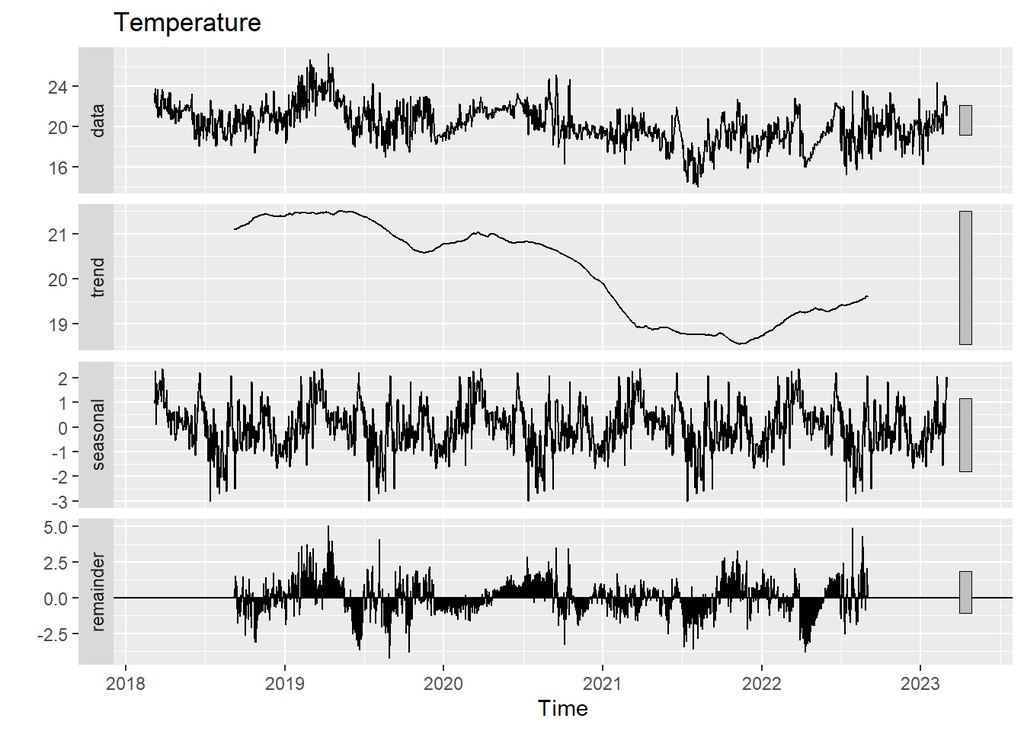

```r
## Decomposition
autoplot(decompose(Region_2imputed[,1]),main="Temperature")
```

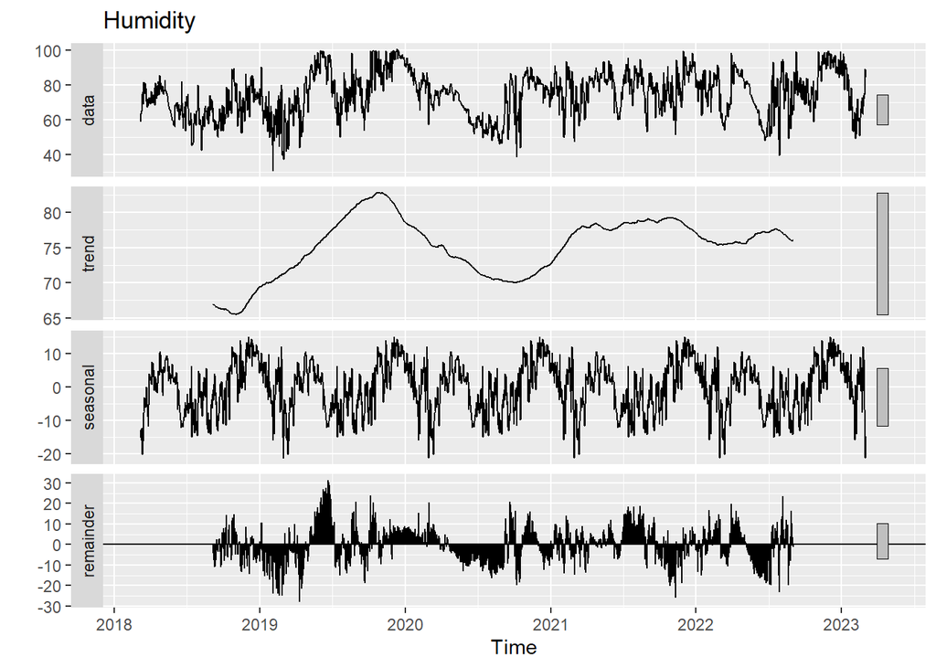

```r
autoplot(decompose(Region_2imputed[,2]),main="Humidity")
```

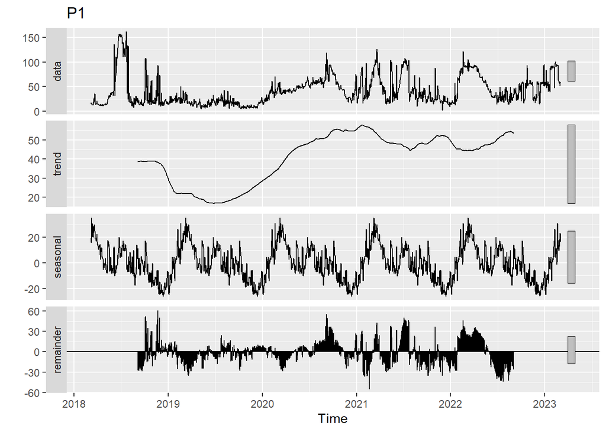

```r
autoplot(decompose(Region_2imputed[,3]),main="P1")
```

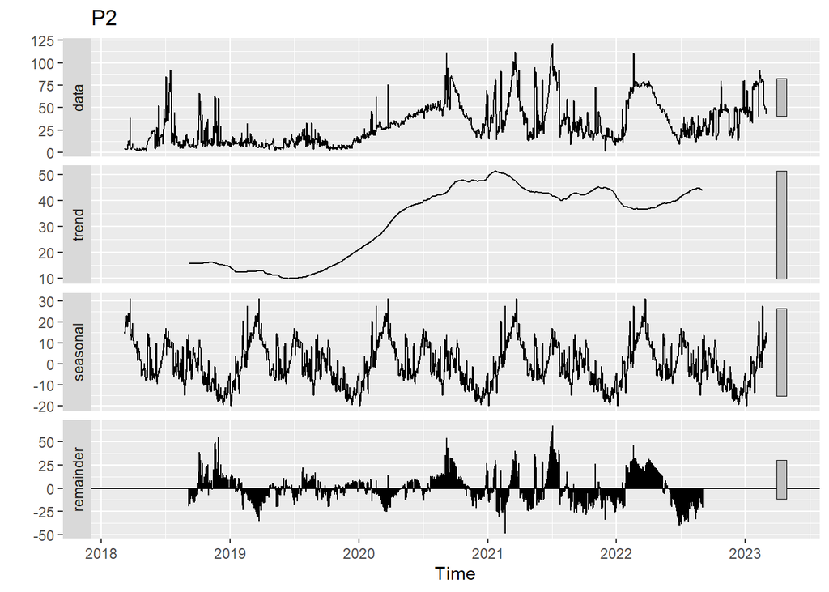

```r
autoplot(decompose(Region_2imputed[,4]),main="P2")
```

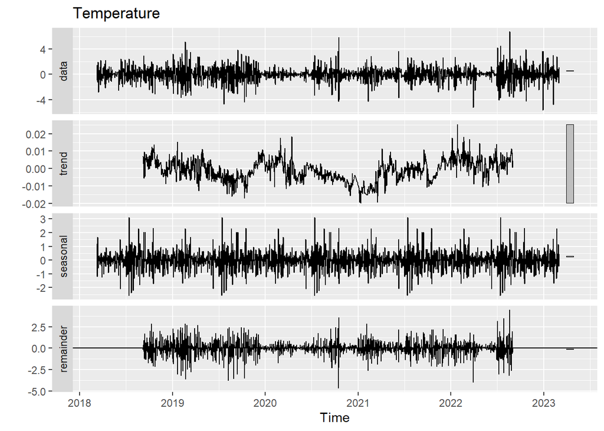

```r
## Differencing
Region2_diff=diff(Region_2imputed,lag = 1)

autoplot(decompose(Region2_diff[,1]),main="Temperature")
```

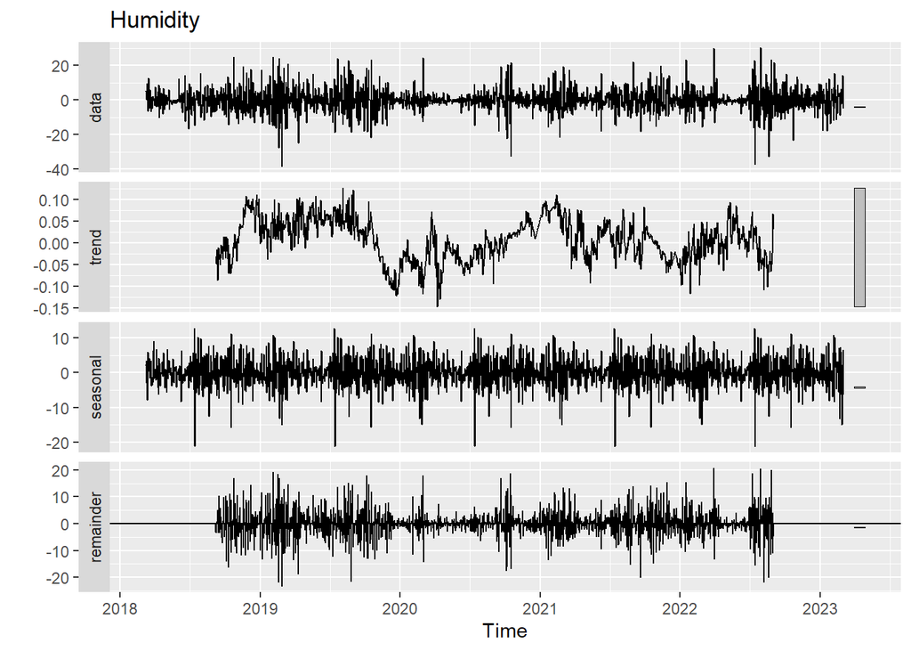

```r
autoplot(decompose(Region2_diff[,2]),main="Humidity")
```

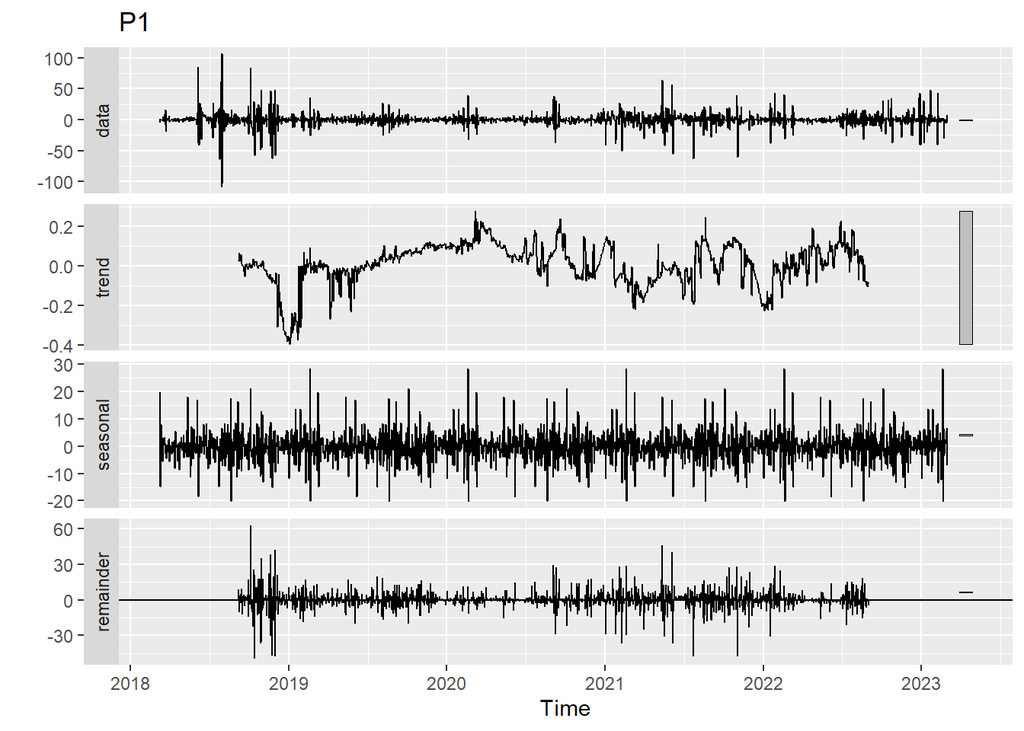

```r
autoplot(decompose(Region2_diff[,3]),main="P1")
```

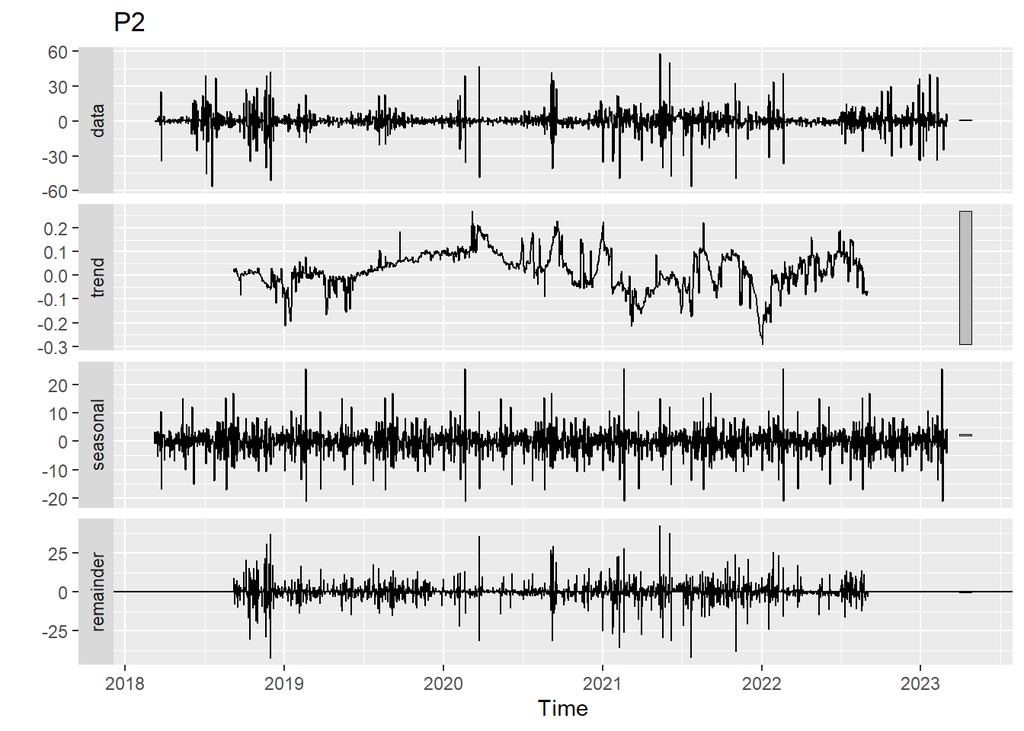

```r
autoplot(decompose(Region2_diff[,4]),main="P2")
```

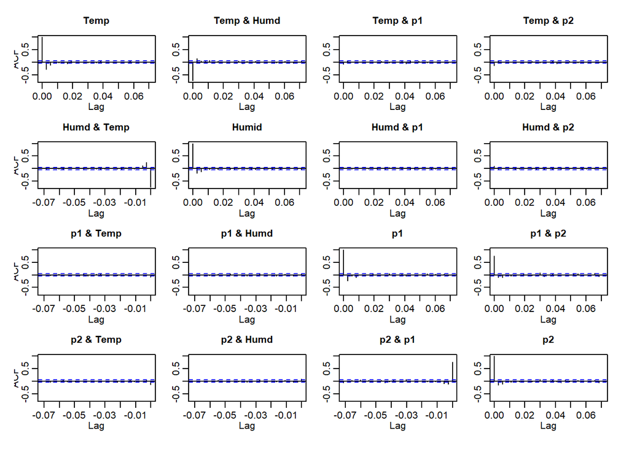

```r
acf(Region2_diff)
```

## Model

### Region 1

```r
Model_1=VAR(Region_1imputed,p=1,type = "const", season = 12)
summary(Model_1) %>% pander::pander()
```

- **names**: *Temp*, *Humid*, *p1* and *p2*
- **varresult**:
  - **Temp**:

    |  | Estimate | Std. Error | t value | Pr(>\|t\|) |
    | --- | --- | --- | --- | --- |
    | **Temp.l1** | 0.9623 | 0.005623 | 171.1 | 0 |
    | **Humid.l1** | 0.01398 | 0.001992 | 7.021 | 3.251e-12 |
    | **p1.l1** | 0.02428 | 0.005757 | 4.218 | 2.608e-05 |
    | **p2.l1** | -0.01711 | 0.006552 | -2.612 | 0.009086 |
    | **const** | -0.2399 | 0.1555 | -1.543 | 0.1231 |
    | **sd1** | 0.07281 | 0.1547 | 0.4706 | 0.638 |
    | **sd2** | 0.1926 | 0.1544 | 1.247 | 0.2125 |
    | **sd3** | 0.1797 | 0.1545 | 1.163 | 0.245 |
    | **sd4** | 0.03806 | 0.1545 | 0.2464 | 0.8054 |
    | **sd5** | 0.01516 | 0.1544 | 0.09813 | 0.9218 |
    | **sd6** | 0.1371 | 0.1544 | 0.8879 | 0.3748 |
    | **sd7** | 0.2092 | 0.1545 | 1.355 | 0.1758 |
    | **sd8** | -0.1525 | 0.1544 | -0.9873 | 0.3236 |
    | **sd9** | 0.28 | 0.1545 | 1.813 | 0.07004 |
    | **sd10** | -0.03759 | 0.1548 | -0.2429 | 0.8081 |
    | **sd11** | 0.2702 | 0.1547 | 1.746 | 0.08097 |

    Fitting linear model: y ~ -1 + .

    | Observations | Residual Std. Error | $R^2$ | Adjusted $R^2$ |
    | --- | --- | --- | --- |
    | 1604 | 1.262 | 0.9579 | 0.9575 |

  - **Humid**:

    |  | Estimate | Std. Error | t value | Pr(>\|t\|) |
    | --- | --- | --- | --- | --- |
    | **Temp.l1** | 0.1312 | 0.02676 | 4.903 | 1.041e-06 |
    | **Humid.l1** | 0.9182 | 0.009476 | 96.9 | 0 |
    | **p1.l1** | -0.1023 | 0.02739 | -3.734 | 0.0001953 |
    | **p2.l1** | 0.1005 | 0.03117 | 3.224 | 0.001291 |
    | **const** | 2.622 | 0.7398 | 3.545 | 0.0004045 |
    | **sd1** | -0.5492 | 0.7361 | -0.746 | 0.4557 |
    | **sd2** | -0.2403 | 0.7348 | -0.327 | 0.7437 |
    | **sd3** | -0.6721 | 0.7351 | -0.9143 | 0.3607 |
    | **sd4** | -0.5485 | 0.7349 | -0.7463 | 0.4556 |
    | **sd5** | -0.6755 | 0.7348 | -0.9193 | 0.3581 |
    | **sd6** | -0.733 | 0.7348 | -0.9976 | 0.3186 |
    | **sd7** | -1.014 | 0.7349 | -1.38 | 0.1677 |
    | **sd8** | -0.05023 | 0.7348 | -0.06835 | 0.9455 |
    | **sd9** | -0.8223 | 0.735 | -1.119 | 0.2634 |
    | **sd10** | -0.5277 | 0.7363 | -0.7167 | 0.4737 |
    | **sd11** | -0.9867 | 0.7362 | -1.34 | 0.1804 |

    Fitting linear model: y ~ -1 + .

    | Observations | Residual Std. Error | $R^2$ | Adjusted $R^2$ |
    | --- | --- | --- | --- |
    | 1604 | 6.003 | 0.8837 | 0.8826 |

  - **p1**:

    |  | Estimate | Std. Error | t value | Pr(>\|t\|) |
    | --- | --- | --- | --- | --- |
    | **Temp.l1** | 0.1237 | 0.02758 | 4.486 | 7.791e-06 |
    | **Humid.l1** | -0.04191 | 0.009769 | -4.29 | 1.891e-05 |
    | **p1.l1** | 0.6713 | 0.02824 | 23.77 | 4.207e-107 |
    | **p2.l1** | 0.215 | 0.03214 | 6.689 | 3.102e-11 |
    | **const** | 3.427 | 0.7627 | 4.493 | 7.527e-06 |
    | **sd1** | 0.8901 | 0.759 | 1.173 | 0.2411 |
    | **sd2** | 1.219 | 0.7576 | 1.61 | 0.1077 |
    | **sd3** | 0.4045 | 0.7579 | 0.5338 | 0.5936 |
    | **sd4** | 0.2989 | 0.7577 | 0.3945 | 0.6933 |
    | **sd5** | -0.289 | 0.7576 | -0.3815 | 0.7029 |
    | **sd6** | 1.204 | 0.7575 | 1.589 | 0.1122 |
    | **sd7** | -0.2847 | 0.7576 | -0.3757 | 0.7072 |
    | **sd8** | 0.7689 | 0.7576 | 1.015 | 0.3103 |
    | **sd9** | 1.031 | 0.7577 | 1.36 | 0.1739 |
    | **sd10** | 0.4233 | 0.7592 | 0.5575 | 0.5772 |
    | **sd11** | -0.3148 | 0.7591 | -0.4147 | 0.6784 |

    Fitting linear model: y ~ -1 + .

    | Observations | Residual Std. Error | $R^2$ | Adjusted $R^2$ |
    | --- | --- | --- | --- |
    | 1604 | 6.189 | 0.7258 | 0.7232 |

  - **p2**:

    |  | Estimate | Std. Error | t value | Pr(>\|t\|) |
    | --- | --- | --- | --- | --- |
    | **Temp.l1** | 0.04428 | 0.01921 | 2.305 | 0.0213 |
    | **Humid.l1** | -0.01222 | 0.006803 | -1.797 | 0.07257 |
    | **p1.l1** | -0.07839 | 0.01967 | -3.986 | 7.024e-05 |
    | **p2.l1** | 0.983 | 0.02238 | 43.92 | 1.68e-276 |
    | **const** | 1.594 | 0.5311 | 3.001 | 0.002729 |
    | **sd1** | 0.6082 | 0.5285 | 1.151 | 0.25 |
    | **sd2** | 0.8099 | 0.5276 | 1.535 | 0.125 |
    | **sd3** | 0.397 | 0.5278 | 0.7523 | 0.452 |
    | **sd4** | 0.4554 | 0.5276 | 0.8631 | 0.3882 |
    | **sd5** | -0.3294 | 0.5276 | -0.6244 | 0.5324 |
    | **sd6** | 0.8856 | 0.5275 | 1.679 | 0.0934 |
    | **sd7** | -0.5 | 0.5276 | -0.9476 | 0.3435 |
    | **sd8** | 0.6042 | 0.5276 | 1.145 | 0.2523 |
    | **sd9** | 0.7224 | 0.5277 | 1.369 | 0.1712 |
    | **sd10** | 0.5495 | 0.5287 | 1.039 | 0.2988 |
    | **sd11** | -0.1249 | 0.5286 | -0.2362 | 0.8133 |

    Fitting linear model: y ~ -1 + .

    | Observations | Residual Std. Error | $R^2$ | Adjusted $R^2$ |
    | --- | --- | --- | --- |
    | 1604 | 4.31 | 0.8194 | 0.8177 |

- **covres**:

  |  | Temp | Humid | p1 | p2 |
  | --- | --- | --- | --- | --- |
  | **Temp** | 1.592 | -4.473 | -0.3911 | -0.6494 |
  | **Humid** | -4.473 | 36.03 | 0.6398 | 1.858 |
  | **p1** | -0.3911 | 0.6398 | 38.3 | 21.72 |
  | **p2** | -0.6494 | 1.858 | 21.72 | 18.57 |

- **corres**:

  |  | Temp | Humid | p1 | p2 |
  | --- | --- | --- | --- | --- |
  | **Temp** | 1 | -0.5907 | -0.05009 | -0.1194 |
  | **Humid** | -0.5907 | 1 | 0.01722 | 0.07181 |
  | **p1** | -0.05009 | 0.01722 | 1 | 0.8144 |
  | **p2** | -0.1194 | 0.07181 | 0.8144 | 1 |

- **logLik**: *-16351*
- **obs**: *1604*
- **roots**: *0.9897*, *0.9206*, *0.9127* and *0.712*
- **type**: const
- **call**: `VAR(y = Region_1imputed, p = 1, type = "const", season = 12L)`

```r
#residual diagnostics
serial.test(Model_1)
```

```
##
##  Portmanteau Test (asymptotic)
##
## data:  Residuals of VAR object Model_1
## Chi-squared = 1120, df = 240, p-value < 2.2e-16
```

```r
arch.test(Model_1)
```

```
##
##  ARCH (multivariate)
##
## data:  Residuals of VAR object Model_1
## Chi-squared = 2309.3, df = 500, p-value < 2.2e-16
```

```r
fcast = predict(Model_1, n.ahead = 5)
fcast
```

```
## $Temp
##          fcst    lower    upper       CI
## [1,] 28.15803 25.68529 30.63077 2.472738
## [2,] 28.19831 24.82343 31.57318 3.374876
## [3,] 27.95685 23.94833 31.96538 4.008522
## [4,] 27.80941 23.30466 32.31416 4.504752
## [5,] 27.80024 22.88553 32.71494 4.914709
##
## $Humid
##          fcst    lower    upper       CI
## [1,] 53.83430 42.06954 65.59905 11.76475
## [2,] 54.56313 38.67450 70.45176 15.88863
## [3,] 56.24782 37.59108 74.90456 18.65674
## [4,] 57.21025 36.49323 77.92727 20.71702
## [5,] 58.35508 36.02676 80.68340 22.32832
##
## $p1
##          fcst    lower    upper       CI
## [1,] 41.97240 29.84292 54.10188 12.12948
## [2,] 39.61325 24.09962 55.12687 15.51363
## [3,] 37.85282 20.41808 55.28755 17.43473
## [4,] 37.06766 18.37690 55.75843 18.69076
## [5,] 36.57874 16.99636 56.16113 19.58239
##
## $p2
##          fcst    lower    upper        CI
## [1,] 35.08721 26.64038 43.53404  8.446831
## [2,] 32.91985 21.60528 44.23441 11.314567
## [3,] 31.09192 17.90537 44.27847 13.186552
## [4,] 30.00995 15.46835 44.55155 14.541601
## [5,] 29.19123 13.61969 44.76276 15.571538
```

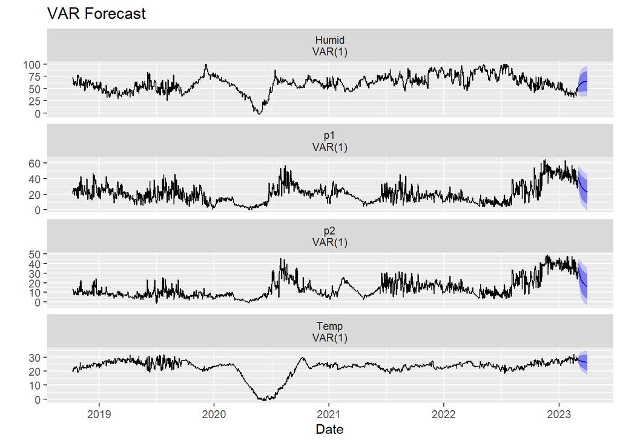

```r
var_forecast = forecast(Model_1, h=30)
autoplot(var_forecast, main="VAR Forecast", xlab="Date")
```

### Region 2

```r
Model_2=VAR(Region_2imputed,p=1,type = "const", season = 12)
summary(Model_2) %>% pander::pander()
```

- **names**: *Temp*, *Humid*, *p1* and *p2*
- **varresult**:
  - **Temp**:

    |  | Estimate | Std. Error | t value | Pr(>\|t\|) |
    | --- | --- | --- | --- | --- |
    | **Temp.l1** | 0.7785 | 0.01818 | 42.83 | 4.848e-277 |
    | **Humid.l1** | -0.004214 | 0.002618 | -1.609 | 0.1077 |
    | **p1.l1** | -2.166e-05 | 0.001644 | -0.01318 | 0.9895 |
    | **p2.l1** | -0.003623 | 0.002026 | -1.788 | 0.07388 |
    | **const** | 4.908 | 0.5297 | 9.267 | 5.281e-20 |
    | **sd1** | -0.007608 | 0.1257 | -0.06054 | 0.9517 |
    | **sd2** | -0.05587 | 0.1255 | -0.4453 | 0.6561 |
    | **sd3** | 0.04296 | 0.1255 | 0.3423 | 0.7322 |
    | **sd4** | -0.00224 | 0.1255 | -0.01785 | 0.9858 |
    | **sd5** | -0.05193 | 0.1255 | -0.4137 | 0.6791 |
    | **sd6** | 0.1667 | 0.1255 | 1.328 | 0.1843 |
    | **sd7** | -0.07232 | 0.1255 | -0.5762 | 0.5646 |
    | **sd8** | 0.06893 | 0.1255 | 0.5492 | 0.5829 |
    | **sd9** | -0.08476 | 0.1257 | -0.6742 | 0.5003 |
    | **sd10** | 0.07248 | 0.1257 | 0.5767 | 0.5642 |
    | **sd11** | -0.01623 | 0.1257 | -0.1291 | 0.8973 |

    Fitting linear model: y ~ -1 + .

    | Observations | Residual Std. Error | $R^2$ | Adjusted $R^2$ |
    | --- | --- | --- | --- |
    | 1819 | 1.092 | 0.6539 | 0.6511 |

  - **Humid**:

    |  | Estimate | Std. Error | t value | Pr(>\|t\|) |
    | --- | --- | --- | --- | --- |
    | **Temp.l1** | 0.674 | 0.1058 | 6.37 | 2.4e-10 |
    | **Humid.l1** | 0.9171 | 0.01524 | 60.18 | 0 |
    | **p1.l1** | -0.0155 | 0.009568 | -1.62 | 0.1055 |
    | **p2.l1** | 0.02683 | 0.01179 | 2.275 | 0.02303 |
    | **const** | -7.622 | 3.083 | -2.472 | 0.01353 |
    | **sd1** | 0.4664 | 0.7316 | 0.6375 | 0.5239 |
    | **sd2** | 1.241 | 0.7304 | 1.7 | 0.08938 |
    | **sd3** | 0.5355 | 0.7306 | 0.733 | 0.4637 |
    | **sd4** | 0.3161 | 0.7306 | 0.4326 | 0.6653 |
    | **sd5** | 0.5475 | 0.7306 | 0.7494 | 0.4537 |
    | **sd6** | -0.8272 | 0.7306 | -1.132 | 0.2577 |
    | **sd7** | 0.4452 | 0.7306 | 0.6094 | 0.5424 |
    | **sd8** | -0.06454 | 0.7306 | -0.08833 | 0.9296 |
    | **sd9** | 0.3196 | 0.7319 | 0.4367 | 0.6624 |
    | **sd10** | -0.1738 | 0.7317 | -0.2375 | 0.8123 |
    | **sd11** | 0.7969 | 0.7316 | 1.089 | 0.2762 |

    Fitting linear model: y ~ -1 + .

    | Observations | Residual Std. Error | $R^2$ | Adjusted $R^2$ |
    | --- | --- | --- | --- |
    | 1819 | 6.357 | 0.7545 | 0.7525 |

  - **p1**:

    |  | Estimate | Std. Error | t value | Pr(>\|t\|) |
    | --- | --- | --- | --- | --- |
    | **Temp.l1** | -0.4464 | 0.1878 | -2.378 | 0.01753 |
    | **Humid.l1** | -0.1125 | 0.02704 | -4.159 | 3.345e-05 |
    | **p1.l1** | 0.8827 | 0.01698 | 51.99 | 0 |
    | **p2.l1** | 0.03895 | 0.02093 | 1.861 | 0.06284 |
    | **const** | 21.14 | 5.471 | 3.864 | 0.0001154 |
    | **sd1** | 0.576 | 1.298 | 0.4437 | 0.6573 |
    | **sd2** | 0.2336 | 1.296 | 0.1803 | 0.857 |
    | **sd3** | -0.7586 | 1.296 | -0.5851 | 0.5585 |
    | **sd4** | 0.3132 | 1.296 | 0.2416 | 0.8091 |
    | **sd5** | 0.4313 | 1.296 | 0.3327 | 0.7394 |
    | **sd6** | 0.635 | 1.296 | 0.4898 | 0.6243 |
    | **sd7** | 0.5926 | 1.296 | 0.4571 | 0.6476 |
    | **sd8** | 0.4965 | 1.296 | 0.383 | 0.7018 |
    | **sd9** | -0.9602 | 1.299 | -0.7394 | 0.4598 |
    | **sd10** | -0.9115 | 1.298 | -0.7021 | 0.4827 |
    | **sd11** | -0.7536 | 1.298 | -0.5805 | 0.5616 |

    Fitting linear model: y ~ -1 + .

    | Observations | Residual Std. Error | $R^2$ | Adjusted $R^2$ |
    | --- | --- | --- | --- |
    | 1819 | 11.28 | 0.854 | 0.8528 |

  - **p2**:

    |  | Estimate | Std. Error | t value | Pr(>\|t\|) |
    | --- | --- | --- | --- | --- |
    | **Temp.l1** | -0.2493 | 0.1436 | -1.736 | 0.08277 |
    | **Humid.l1** | -0.06765 | 0.02069 | -3.27 | 0.001096 |
    | **p1.l1** | -0.002641 | 0.01299 | -0.2033 | 0.8389 |
    | **p2.l1** | 0.9254 | 0.01601 | 57.81 | 0 |
    | **const** | 12.59 | 4.185 | 3.008 | 0.002669 |
    | **sd1** | 0.9026 | 0.993 | 0.9089 | 0.3635 |
    | **sd2** | -0.3822 | 0.9914 | -0.3855 | 0.6999 |
    | **sd3** | 0.4854 | 0.9917 | 0.4895 | 0.6246 |
    | **sd4** | 0.1047 | 0.9916 | 0.1055 | 0.916 |
    | **sd5** | 0.9314 | 0.9917 | 0.9392 | 0.3478 |
    | **sd6** | 0.06391 | 0.9917 | 0.06445 | 0.9486 |
    | **sd7** | 0.5472 | 0.9917 | 0.5518 | 0.5811 |
    | **sd8** | 0.4697 | 0.9917 | 0.4737 | 0.6358 |
    | **sd9** | 0.2652 | 0.9934 | 0.267 | 0.7895 |
    | **sd10** | -0.04056 | 0.9931 | -0.04084 | 0.9674 |
    | **sd11** | 0.1076 | 0.9931 | 0.1083 | 0.9138 |

    Fitting linear model: y ~ -1 + .

    | Observations | Residual Std. Error | $R^2$ | Adjusted $R^2$ |
    | --- | --- | --- | --- |
    | 1819 | 8.628 | 0.8668 | 0.8657 |

- **covres**:

  |  | Temp | Humid | p1 | p2 |
  | --- | --- | --- | --- | --- |
  | **Temp** | 1.192 | -5.021 | -1.023 | -1.341 |
  | **Humid** | -5.021 | 40.41 | 2.641 | 4.743 |
  | **p1** | -1.023 | 2.641 | 127.2 | 74.29 |
  | **p2** | -1.341 | 4.743 | 74.29 | 74.45 |

- **corres**:

  |  | Temp | Humid | p1 | p2 |
  | --- | --- | --- | --- | --- |
  | **Temp** | 1 | -0.7233 | -0.08302 | -0.1423 |
  | **Humid** | -0.7233 | 1 | 0.03684 | 0.08648 |
  | **p1** | -0.08302 | 0.03684 | 1 | 0.7634 |
  | **p2** | -0.1423 | 0.08648 | 0.7634 | 1 |

- **logLik**: *-20654*
- **obs**: *1819*
- **roots**: *0.9388*, *0.9029*, *0.8505* and *0.8116*
- **type**: const
- **call**: `VAR(y = Region_2imputed, p = 1, type = "const", season = 12L)`

```r
#residual diagnostics
serial.test(Model_2)
```

```
##
##  Portmanteau Test (asymptotic)
##
## data:  Residuals of VAR object Model_2
## Chi-squared = 800.45, df = 240, p-value < 2.2e-16
```

```r
arch.test(Model_2)
```

```
##
##  ARCH (multivariate)
##
## data:  Residuals of VAR object Model_2
## Chi-squared = 2710, df = 500, p-value < 2.2e-16
```

```r
fcast = predict(Model_2, n.ahead = 5)
fcast
```

```
## $Temp
##          fcst    lower    upper       CI
## [1,] 21.51454 19.37426 23.65482 2.140278
## [2,] 21.19594 18.45367 23.93821 2.742270
## [3,] 20.86931 17.80142 23.93720 3.067891
## [4,] 20.63655 17.37536 23.89775 3.261197
## [5,] 20.45717 17.07608 23.83827 3.381092
##
## $Humid
##          fcst    lower     upper       CI
## [1,] 85.20248 72.74353  97.66142 12.45894
## [2,] 84.96849 68.70158 101.23541 16.26692
## [3,] 85.49592 66.95951 104.03232 18.53640
## [4,] 84.95062 64.89951 105.00173 20.05111
## [5,] 84.73389 63.60762 105.86015 21.12627
##
## $p1
##          fcst     lower    upper       CI
## [1,] 53.71279 31.605104 75.82049 22.10769
## [2,] 50.28623 20.425047 80.14741 29.86118
## [3,] 47.49054 12.464491 82.51658 35.02605
## [4,] 45.78259  6.950888 84.61429 38.83170
## [5,] 44.93979  3.160801 86.71877 41.77899
##
## $p2
##          fcst     lower    upper       CI
## [1,] 46.75051 29.839568 63.66146 16.91095
## [2,] 44.25153 21.231582 67.27147 23.01994
## [3,] 42.19145 15.011673 69.37122 27.17977
## [4,] 40.23068  9.930564 70.53079 30.30011
## [5,] 39.41825  6.667354 72.16914 32.75089
```

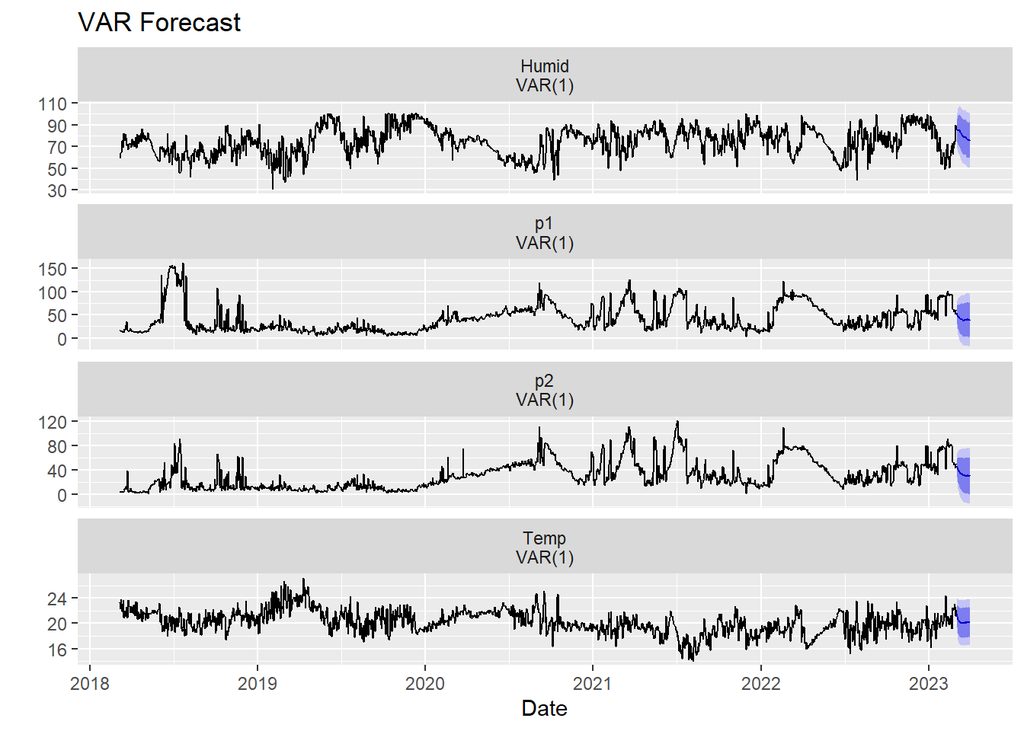

```r
var_forecast = forecast(Model_2, h=30)
autoplot(var_forecast, main="VAR Forecast", xlab="Date")
```